# Data Principles

# Case Study 1: Data Matrix

Data collected on students in a statistics class on a variety of variables:

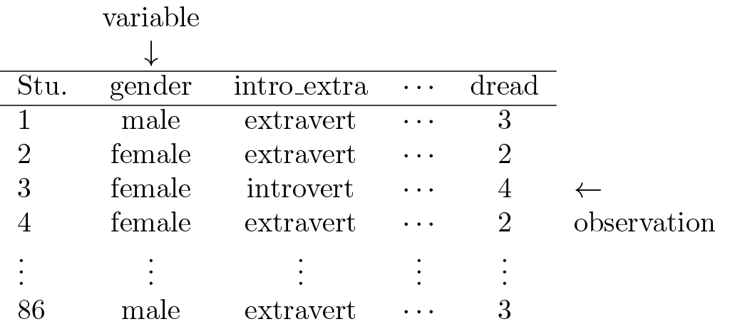

Example Data Matrix

# Case Study 1: Identify Types of Variables

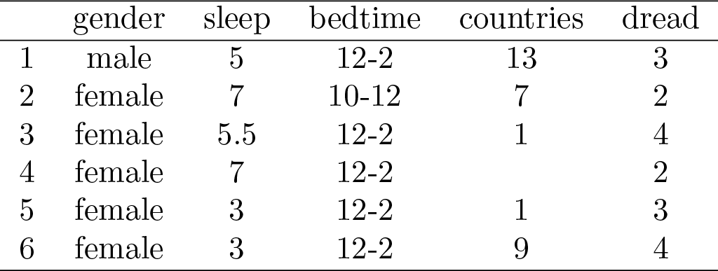

- **gender:** nominal categorical
- **sleep:** continuous numerical
- **bedtime:** ordinal categorical
- **countries:** discrete numerical
- **dread:** ordinal categorical - could also be used as numerical

# R Variables

**How are variables created and stored in R?**

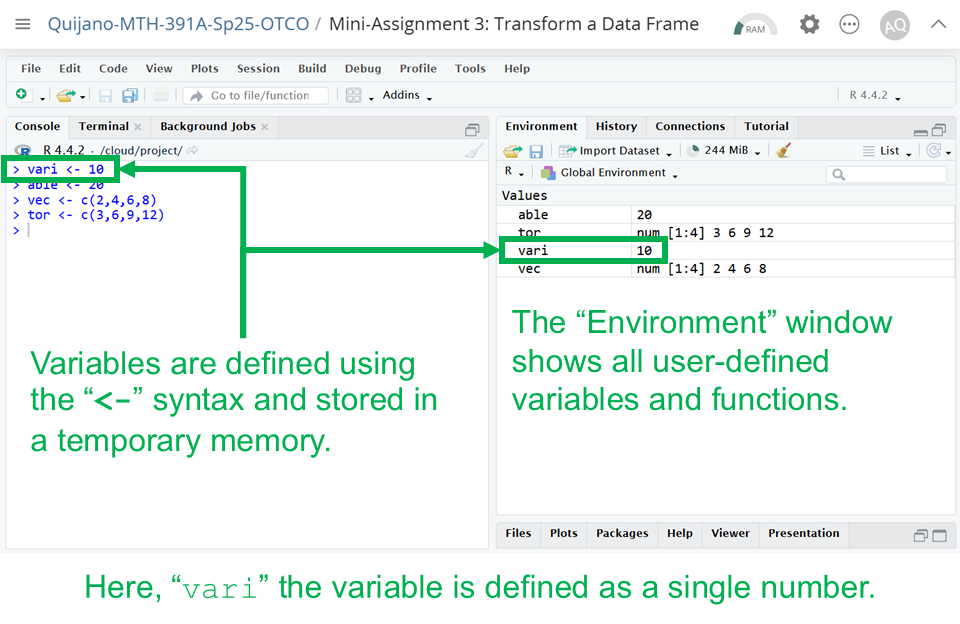

$\dagger$ Create a variable named `ria` and initially define it as a number. Then, redefine `ria` as a vector. What happens to the original value of `ria` (the number) after it is redefined as a vector?

# Introduction to Data Frames

**What is a data frame?**

- A data frame is a key data structure in R used for storing data sets.
- It organizes data into rows and columns, similar to a spreadsheet.
- Each column can contain data of a different variable type (e.g., numeric, character, vector).

# Data Frame Key Characteristics

**Base R:** These data frames are data structures that comes with base R.

[figure not shown]

**Tibbles:** Tibbles are special kinds of data frames using the `tibble` package.

[figure not shown]

$\star$ A base R data frame can be converted to a tibble data frame using the `tibble()` function. The `iris` data set is a built-in data in the `datasets` packages, which comes with base R.

# R Packages

**What are R packages?**

- Packages in R are collections of functions, data, and documentation that extend the capabilities of base R.
- It includes manuals and examples to help users understand how to use the package.

# Base R versus R Packages

| **Aspect** | **Base R** | **R Packages** |
| --- | --- | --- |
| *Availability* | Comes pre-installed with R | Must be installed and loaded |
| *Functionality* | Offers basic statistical and programming tools | Provides advanced or specialized tools not included in base R |
| *Customization* | Limited to what’s already available | Highly customizable; users can install or even create their own packages |
| *Performance* | Base R can sometimes be slower or more verbose | Packages often include optimized or simpler syntax for complex tasks |
| *Speciality* | Limited only for basic statistics | Often built for a specific purpose or knowledge |

# The `tidyverse` Package

`tidyverse` is a collection of packages suited for data processing and visualization.

[figure not shown]

Core packages specifically for data processing:

[figure not shown]

[figure not shown]

[figure not shown]

- `dplyr` provides a grammar for data transformation.
- `tidyr` provides a set of functions that help you get data in consistent form.
- `tibble` is a data frame that prioritize simplicity, enforcing stricter checks to promote cleaner, more expressive code.

# Installing Packages

**How to install R Packages?**

The following two methods installs the `tidyverse` package.

- **Using the “Tools” menu**

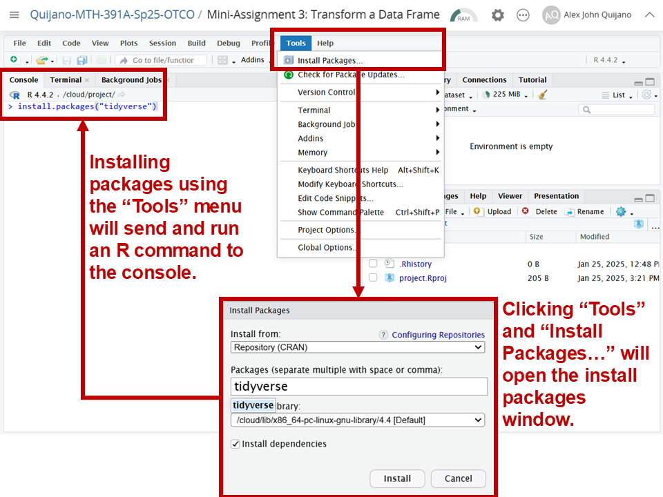

- **Using the R Console Directly**

```r
install.packages("tidyverse")
```

$\dagger$ Try the above code sequence in your console. Then, install a different package called `plotly`.

$\star$ Knitting an RMarkdown with this function in a code chunk will give you an error. You need to run it directly on the console.

# Loading Packages

**How to load R Packages?**

The function `library()` loads any installed package. In this case `library("tidyverse")` loads the `tidyverse` package specifically.

```r
library("tidyverse")
```

$\dagger$ Try the above code sequence in your console. Then, load the package `plotly`.

# Data Frame Subsetting

**How to Subset a Data Frame?** Data frames are organized into rows and columns and can be accessed in the following ways:

- Accessing a column by Name using `$`

```r
iris$Species
```

- Accessing a column by name using `[]`

```r
iris[,"Species"]
```

- Accessing multiple columns using a vector of names

```r
iris[,c("Species","Sepal.Length")]
```

- Accessing rows by an index

```r
iris[42,]
```

- Accessing specific rows and columns by index or name

```r
iris[42,c("Species","Sepal.Length")]
```

- Accessing specific rows according to some condition

```r
iris[iris$Species == "setosa",]
```

$\dagger$ Try to subset the `iris` data set, accessing the “viriginica” in the `Species` column.

$\star$ The above examples uses the `iris` data set, which comes with base R.

# Subset a Data Frame based on Conditions

**Define Data Frame as a Tibble**

```r
iris_tibble <- tibble(iris)
```

**Example:** The following code sequence subsets the `iris` dataframe (in tibble form) to include only the “versicolor” species, and all rows with `Sepal.Length` at least $6$.

```r
# subset by species to match "versicolor"
iris_versicolor <- iris_tibble[iris_tibble$Species == "versicolor",]
# subset rows with Sepal.Length at least 6
iris_versicolor2 <- iris_versicolor[iris_versicolor$Sepal.Length >= 6,]
# display result
glimpse(iris_versicolor2)
```

$\star$ The code sequence above uses different variable definitions to track subsetting conditions sequentially.

# Activity: Data Sub-Setting and Identifying Variables

1. Log-in to Posit Cloud and open the R Studio assignment *M 1/27 - Data Sub-Setting and Identifying Variables*.
2. Make sure you are in the current working directory. Rename the `.Rmd` file by replacing `[name]` with your name using the format `[First name][Last initial]`. Then, open the `.Rmd` file.
3. Change the author in the YAML header.
4. Read the provided instructions.
5. Answer all exercise problems on the designated sections.

# References

Diez, D. M., Barr, C. D., & Çetinkaya-Rundel, M. (2012). *OpenIntro statistics* (4th ed.). OpenIntro. https://www.openintro.org/book/os/

Speegle, Darrin and Clair, Bryan. (2021). *Probability, statistics, and data: A fresh approach using r*. Chapman; Hall/CRC. https://probstatsdata.com/